# Lab 3 - Parte 2:Prevendo Evasão

André Victor de Andrade Lopes

3 de Março de 2017

## 1. Preparando os Dados

### 1.1. Obtendo os dados e filtrando

O primeiro passo a ser feito é obter os dados e filtrar o que é importante para a naĺise.

```r
training.data.raw <- read.csv('treino_classificacao_v2.csv',header=T)

# Get only the necessary columns: Identification, Year and Evasion
training.by.year <- training.data.raw[c(1,4,7)]
#Remove duplicated info from the same student
training.by.year <- aggregate(MAT_TUR_ANO ~ MAT_ALU_MATRICULA + EVADIU, training.by.year,  FUN= mean)
#Get only the data of students that evade
evasions.by.year <- subset(training.by.year, EVADIU)
training.data.raw <- training.data.raw %>% mutate(disciplina = as.factor(gsub(" ",".",disciplina)))

data.by.params <- spread(training.data.raw, key = disciplina, value = MAT_MEDIA_FINAL)
data.by.params[is.na(data.by.params)] <- 0
data.by.params <- data.by.params[c(1,6,7,8,9,10,11)]
data.by.params <- data.by.params %>%
  group_by(MAT_ALU_MATRICULA) %>%
  summarise_each(funs(sum))

data.by.params <- merge(data.by.params, training.by.year, by = "MAT_ALU_MATRICULA")
```

### 1.2. Adicionar novas variáveis

Agora, iremos criar as variáveis que foram elaboradas na primeira parte da anaĺise: Quantidade de Cadeiras com nota baixo de 5, e se o estudante perdeu mais de 3 cadeiras.

```r
data.by.params["Perdeu3"] <- 0
data.by.params["CadeirasPerdidas"] <- 0

for (j in 1:nrow(data.by.params)){
  x <- data.by.params[j,]
  tt <- 0
  for(i in 2:7) {
    col <- x[i]
     if (col < 5){
       tt<- tt+ 1
       }
  }
    data.by.params[j,11]<- tt
  if(tt>3){
    data.by.params[j,10] <- 1
  }
}
```

### 1.3. Dividir amostra em Treino e Teste

Para treinarmos os modelos e testá-los, separamos a amostra em duas fatias: 70% para treino, 30% para teste.

```r
## 70% da amostra
smp_size <- floor(0.70 * nrow(data.by.params))

set.seed(123)
train_ind <- sample(seq_len(nrow(data.by.params)), size = smp_size)

data.by.params <-  subset( data.by.params, select = -MAT_ALU_MATRICULA )
data.by.params$EVADIU <- as.numeric(data.by.params$EVADIU)
colnames(data.by.params)[3] <- "IC"

#Divisão de teste e treino.
train <- data.by.params[train_ind, ]
test <- data.by.params[-train_ind, ]
```

## 2. Regressão Logística

### 2.1. Treino

A seguir, definimos o modelo de regressão logística e, ao analisarmos os coeficientes, definimos as variáveis que são mais importantes para o modelo.

```r
model.logit <- glm(EVADIU ~.,family=binomial(link='logit'),data=train)
```

### 2.2. Análise sobre o modelo

#### 2.2.1. As variáveis

```r
summary(model.logit)
```

```
Call:
glm(formula = EVADIU ~ ., family = binomial(link = "logit"),
    data = train)

Deviance Residuals:
    Min       1Q   Median       3Q      Max
-1.8553  -0.2242  -0.1239  -0.0647   3.4367

Coefficients:
                                         Estimate Std. Error z value
(Intercept)                            -333.08283   80.84155  -4.120
Álgebra.Vetorial.e.Geometria.Analítica   -0.03261    0.09352  -0.349
Cálculo.Diferencial.e.Integral.I          0.02132    0.10824   0.197
IC                                       -0.25702    0.07824  -3.285
Laboratório.de.Programação.I             -0.15662    0.23028  -0.680
Leitura.e.Produção.de.Textos             -0.10478    0.05978  -1.753
Programação.I                            -0.12053    0.23152  -0.521
MAT_TUR_ANO                               0.16564    0.04030   4.110
Perdeu3                                  -1.56739    0.80642  -1.944
CadeirasPerdidas                          0.45537    0.31919   1.427
                                       Pr(>|z|)
(Intercept)                            3.79e-05 ***
Álgebra.Vetorial.e.Geometria.Analítica  0.72728
Cálculo.Diferencial.e.Integral.I        0.84385
IC                                      0.00102 **
Laboratório.de.Programação.I            0.49643
Leitura.e.Produção.de.Textos            0.07964 .
Programação.I                           0.60263
MAT_TUR_ANO                            3.96e-05 ***
Perdeu3                                 0.05194 .
CadeirasPerdidas                        0.15368
---
Signif. codes:  0 '***' 0.001 '**' 0.01 '*' 0.05 '.' 0.1 ' ' 1

(Dispersion parameter for binomial family taken to be 1)

    Null deviance: 607.79  on 944  degrees of freedom
Residual deviance: 294.48  on 935  degrees of freedom
AIC: 314.48

Number of Fisher Scoring iterations: 7
```

A variável referente a Introdução a computação apresenta o valor de Standard Error baixo, e o p valor baixo também, assim consideramos que esta é uma variável interessante para o modelo. Outra variável que também tem o p valor baixo, e o Standard Error baixo é “MATTUR_ANO” que é a variável referente ao ano de ingresso do estudante. Assim, essa variável também é considerada importante para o modelo, o que de certa forma faz sentido uma vez que na primeira parte da análise percebemos que a quantidade de evasão vem aumentando no decorrer dos anos.

#### 2.2.2. Desvio

```r
anova(model.logit,test="Chisq")
```

```
Analysis of Deviance Table

Model: binomial, link: logit

Response: EVADIU

Terms added sequentially (first to last)

                                       Df Deviance Resid. Df Resid. Dev
NULL                                                     944     607.79
Álgebra.Vetorial.e.Geometria.Analítica  1  169.629       943     438.16
Cálculo.Diferencial.e.Integral.I        1    8.074       942     430.09
IC                                      1   92.783       941     337.30
Laboratório.de.Programação.I            1   10.639       940     326.66
Leitura.e.Produção.de.Textos            1    9.069       939     317.60
Programação.I                           1    0.419       938     317.18
MAT_TUR_ANO                             1   18.804       937     298.37
Perdeu3                                 1    1.854       936     296.52
CadeirasPerdidas                        1    2.036       935     294.48
                                        Pr(>Chi)
NULL
Álgebra.Vetorial.e.Geometria.Analítica < 2.2e-16 ***
Cálculo.Diferencial.e.Integral.I        0.004490 **
IC                                     < 2.2e-16 ***
Laboratório.de.Programação.I            0.001107 **
Leitura.e.Produção.de.Textos            0.002600 **
Programação.I                           0.517372
MAT_TUR_ANO                            1.448e-05 ***
Perdeu3                                 0.173274
CadeirasPerdidas                        0.153631
---
Signif. codes:  0 '***' 0.001 '**' 0.01 '*' 0.05 '.' 0.1 ' ' 1
```

Analisando os desvios e o p-valor, podemos perceber que os p-valor das variáveis referentes a nota de Introdução a Computação e ano de matricula do estudante são bem baixos, ou seja, o modelo sem as variáveis não expressa tão bem a variância que o modelo com as variáveis.

#### 2.2.3. Acurácia

Na acurácia, analisamos a proporção das observações corretamente classificadas. Para o modelo de regressão logística, temos que mais de 90% dos dados foram classificados corretamente.

```r
fitted.results <- predict(model.logit,test,type='response')
fitted.results <- ifelse(fitted.results > 0.5,1,0)

misClasificError <- mean(fitted.results != test$EVADIU)
print(paste('Accuracy',1-misClasificError))
```

```
[1] "Accuracy 0.960591133004926"
```

#### 2.2.4. Precisão e Recall

```r
predicted<-ifelse(fitted.results> 0.5,1,0)

actual <- as.numeric(test$EVADIU)

confusionMatrix(actual, predicted, positive = '1')
```

```
Confusion Matrix and Statistics

          Reference
Prediction   0   1
         0 365   8
         1   8  25

               Accuracy : 0.9606
                 95% CI : (0.9368, 0.9773)
    No Information Rate : 0.9187
    P-Value [Acc > NIR] : 0.0005486

                  Kappa : 0.7361
 Mcnemar's Test P-Value : 1.0000000

            Sensitivity : 0.75758
            Specificity : 0.97855
         Pos Pred Value : 0.75758
         Neg Pred Value : 0.97855
             Prevalence : 0.08128
         Detection Rate : 0.06158
   Detection Prevalence : 0.08128
      Balanced Accuracy : 0.86806

       'Positive' Class : 1
```

A partir da Confusion Matrix podemos obter os valores: **TP:** true-positive = 25 **TN:** true-negative = 365 **FP:** false-positive = 8 **FN:** false-negative = 8

**Precisão:** Observações classificadas como positiva corretamente *(Ou seja, a observação foi classificada como positiva e é de fato positiva)* = TP / (TP+FP) =

```r
precisao.logist <-25 / (25+8)
print(precisao.logist)
```

```
[1] 0.7575758
```

**Recall:** Observações positiva classificadas corretamente *(Ou seja, a observação é positiva e foi classificada como tal)* = TP / (TP+FN)

```r
recall.logist <-25 / (25+8)
print(recall.logist)
```

```
[1] 0.7575758
```

Considerando Acurácia, Precisão e Recall, temos que a predição teve um bom resultado. Todos os valores estão acima de 70%.

## 3. Árvore de Decisão

```r
library(rpart)
```

### 3.1. Treino

```r
model.tree = rpart(EVADIU ~ . , data=train)
```

### 3.2. Análise do Modelo

```r
#library(gmodels)
predicted.tree <- predict(model.tree,test)
predicted.tree <-ifelse(predicted.tree> 0.5,1,0)
#predicted.tree <- subset(predicted.tree, select = 2)
confusionMatrix(actual, predicted.tree, positive = '1')
```

```
Confusion Matrix and Statistics

          Reference
Prediction   0   1
         0 367   6
         1   8  25

               Accuracy : 0.9655
                 95% CI : (0.9428, 0.981)
    No Information Rate : 0.9236
    P-Value [Acc > NIR] : 0.000353

                  Kappa : 0.7626
 Mcnemar's Test P-Value : 0.789268

            Sensitivity : 0.80645
            Specificity : 0.97867
         Pos Pred Value : 0.75758
         Neg Pred Value : 0.98391
             Prevalence : 0.07635
         Detection Rate : 0.06158
   Detection Prevalence : 0.08128
      Balanced Accuracy : 0.89256

       'Positive' Class : 1
```

Temos que a acurácia é praticamente igual a obtida anteriormente (97%). A partir da Confusion Matrix podemos obter os valores: **TP:** true-positive = 25 **TN:** true-negative = 367 **FP:** false-positive = 8 **FN:** false-negative = 6

**Precisão:** Observações classificadas como positiva corretamente *(Ou seja, a observação foi classificada como positiva e é de fato positiva)* = TP / (TP+FP) =

```r
precisao.tree <-25 / (25+8)
print(precisao.tree)
```

```
[1] 0.7575758
```

**Recall:** Observações positiva classificadas corretamente *(Ou seja, a observação é positiva e foi classificada como tal)* = TP / (TP+FN)

```r
recall.tree<-25 / (25+6)
print(recall.tree)
```

```
[1] 0.8064516
```

Considerando Acurácia, Precisão e Recall, temos que a predição teve um bom resultado. Todos os valores estão acima de 70%. Em comparação aos resultados anteriores, temos que agora, o valor do recall é maior (cerca de 80%).

## 4. Controle de Overfitting

### 4.1. Regressão Lógica

#### 4.1.1. Ridge

Utilizaremos a função glmnet para desenvolver modelos com valores de lambda diferentes. Para tentarmos encontrar o melhor valor.

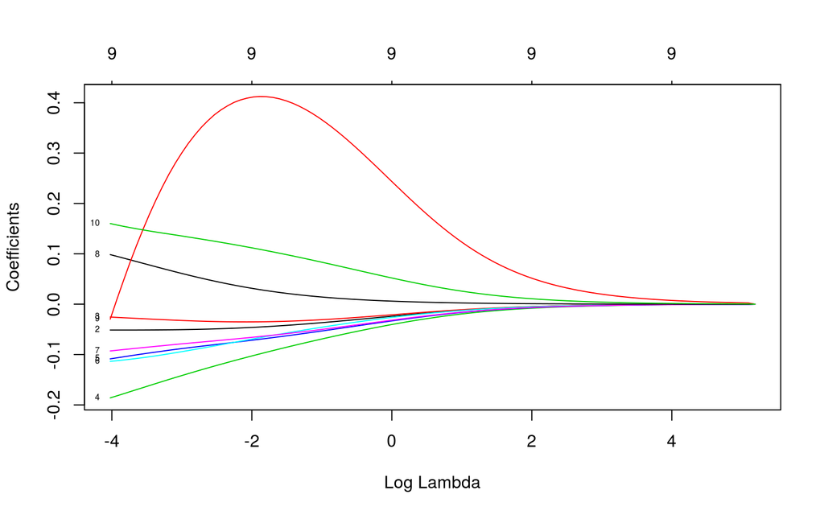

```r
set.seed(123)

model.ridge = glmnet(x = model.matrix( ~ . -EVADIU, train),
                y = train$EVADIU,
                alpha = 0,
                family = 'binomial')
plot(model.ridge, xvar = "lambda", label = T)
```

Podemos ver que quando log de lambda é 4, todos os coeficientes são essencialmente zero. A função cv.glmnet fará a validação cruzada.

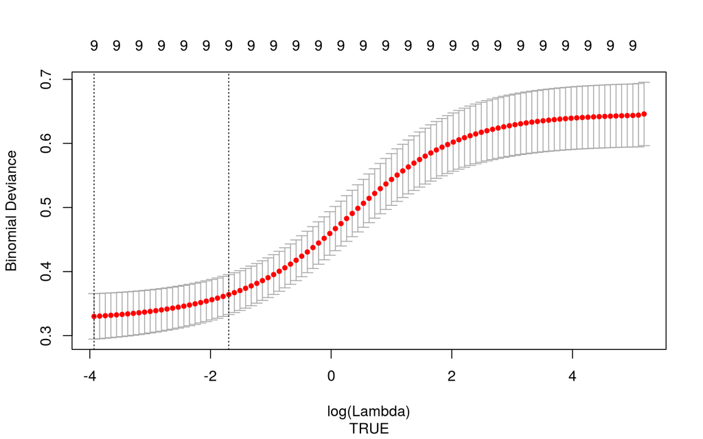

```r
cv.ridge = cv.glmnet(model.matrix( ~ .  -EVADIU, train), y=train$EVADIU, alpha=0, family="binomial")

plot(cv.ridge, sub = T)
```

#### 4.1.2. Lasso O modelo de regressão é ajustado com a função glmnet, sendo alpha igual a 1.

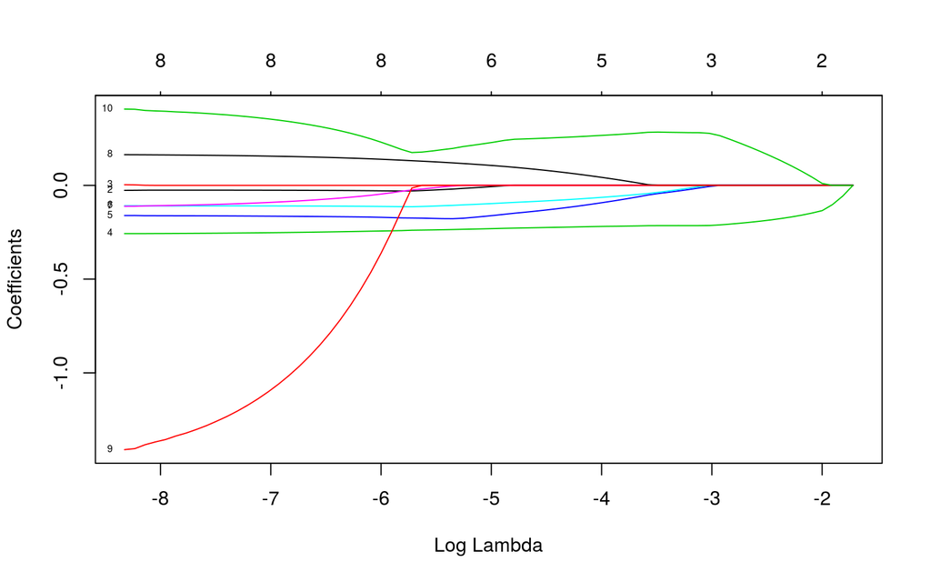

```r
set.seed(123)
model.lasso = glmnet(x = model.matrix( ~ . -EVADIU, train),
                y = train$EVADIU,
                alpha = 1,
                family = 'binomial')
plot(model.lasso, xvar = "lambda", label = T)
```

Podemos visualizar os coeficientes do modelo:

```r
coef(model.lasso)[,10]
```

```
                           (Intercept)
                            -1.5537563
                           (Intercept)
                             0.0000000
Álgebra.Vetorial.e.Geometria.Analítica
                             0.0000000
      Cálculo.Diferencial.e.Integral.I
                             0.0000000
                                    IC
                            -0.1908319
          Laboratório.de.Programação.I
                             0.0000000
          Leitura.e.Produção.de.Textos
                             0.0000000
                         Programação.I
                             0.0000000
                           MAT_TUR_ANO
                             0.0000000
                               Perdeu3
                             0.0000000
                      CadeirasPerdidas
                             0.1800332
```

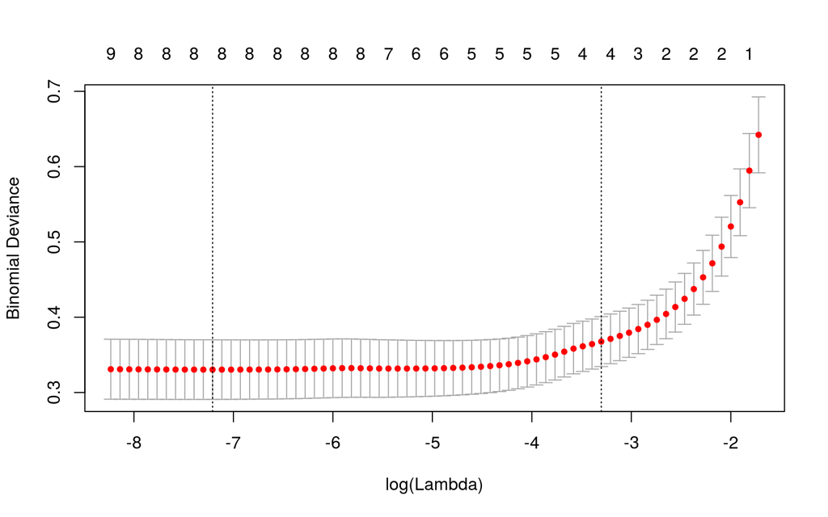

```r
cv.lasso = cv.glmnet(model.matrix( ~ . -EVADIU, train), y=train$EVADIU, alpha=1, family="binomial")
plot(cv.lasso)
```

e assim, definimos o melhor modelo:

```r
set.seed(123)
fitControl = trainControl(method = "cv", number = 10)
best.glm.model = model.lasso = train(EVADIU ~ IC + CadeirasPerdidas,
                   data=train,
                   method="glm",
                   family="binomial",
                   preProcess = c('scale', 'center'),
                   trControl = fitControl,
                   na.action = na.omit)
```

### 4.2. Árvore de decisão

```r
dt.control = rpart.control(maxdepth=30)

model.tree.again = rpart(EVADIU ~ . ,
                           data=train,
                           method="class",
                           control=dt.control)

printcp(model.tree.again)
```

```
Classification tree:
rpart(formula = EVADIU ~ ., data = train, method = "class", control = dt.control)

Variables actually used in tree construction:
[1] CadeirasPerdidas MAT_TUR_ANO

Root node error: 93/945 = 0.098413

n= 945

       CP nsplit rel error  xerror     xstd
1 0.47312      0   1.00000 1.00000 0.098461
2 0.11828      1   0.52688 0.52688 0.073291
3 0.01000      2   0.40860 0.40860 0.064938
```

```r
best.tree = prune(model.tree.again,
 + model.tree.again$cptable[which.min(model.tree.again$cptable[,"xerror"]),"CP"])
```

### 4.3. Acurácia, precisão e recall

#### 4.3.1. Regressão Logística

```r
pred.l.best <- predict(best.glm.model, test)

pred.l.best<-ifelse(pred.l.best> 0.5,1,0)

confusionMatrix(actual, pred.l.best, positive = '1')
```

```
Confusion Matrix and Statistics

          Reference
Prediction   0   1
         0 364   9
         1   6  27

               Accuracy : 0.9631
                 95% CI : (0.9398, 0.9792)
    No Information Rate : 0.9113
    P-Value [Acc > NIR] : 3.578e-05

                  Kappa : 0.7625
 Mcnemar's Test P-Value : 0.6056

            Sensitivity : 0.75000
            Specificity : 0.98378
         Pos Pred Value : 0.81818
         Neg Pred Value : 0.97587
             Prevalence : 0.08867
         Detection Rate : 0.06650
   Detection Prevalence : 0.08128
      Balanced Accuracy : 0.86689

       'Positive' Class : 1
```

Temos que a acurácia é praticamente igual a obtida anteriormente (96%). A partir da Confusion Matrix podemos obter os valores: **TP:** true-positive = 27 **TN:** true-negative = 364 **FP:** false-positive = 6 **FN:** false-negative = 9

**Precisão:** Observações classificadas como positiva corretamente *(Ou seja, a observação foi classificada como positiva e é de fato positiva)* = TP / (TP+FP) =

```r
precisao.logist.best <-27 / (27+6)
print(precisao.logist.best)
```

```
[1] 0.8181818
```

**Recall:** Observações positiva classificadas corretamente *(Ou seja, a observação é positiva e foi classificada como tal)* = TP / (TP+FN)

```r
recall.logist.best <-27 / (27+9)
print(recall.logist.best)
```

```
[1] 0.75
```

Considerando Acurácia, Precisão e Recall, temos que a predição teve um bom resultado. Todos os valores estão acima de 70%. Em comparação aos resultados anteriores, temos que agora, a precisão é maior (cerca de 82%).

#### 4.3.2. Árvore de Decisão

```r
pred.t.best <- predict(best.tree, test)

pred.t.best<-ifelse(pred.t.best> 0.5,1,0)
pred.t.best<- subset(pred.t.best, select = 2)

confusionMatrix(actual, pred.t.best, positive = '1')
```

```
Confusion Matrix and Statistics

          Reference
Prediction   0   1
         0 367   6
         1   8  25

               Accuracy : 0.9655
                 95% CI : (0.9428, 0.981)
    No Information Rate : 0.9236
    P-Value [Acc > NIR] : 0.000353

                  Kappa : 0.7626
 Mcnemar's Test P-Value : 0.789268

            Sensitivity : 0.80645
            Specificity : 0.97867
         Pos Pred Value : 0.75758
         Neg Pred Value : 0.98391
             Prevalence : 0.07635
         Detection Rate : 0.06158
   Detection Prevalence : 0.08128
      Balanced Accuracy : 0.89256

       'Positive' Class : 1
```

Temos que a acurácia é praticamente igual a obtida anteriormente (96%). A partir da Confusion Matrix podemos obter os valores: **TP:** true-positive = 25 **TN:** true-negative = 367 **FP:** false-positive = 8 **FN:** false-negative = 6

**Precisão:** Observações classificadas como positiva corretamente *(Ou seja, a observação foi classificada como positiva e é de fato positiva)* = TP / (TP+FP) =

```r
precisao.tree.best <-25 / (25+8)
print(precisao.tree.best)
```

```
[1] 0.7575758
```

**Recall:** Observações positiva classificadas corretamente *(Ou seja, a observação é positiva e foi classificada como tal)* = TP / (TP+FN)

```r
recall.tree.best <-25 / (25+6)
print(recall.tree.best)
```

```
[1] 0.8064516
```

Considerando Acurácia, Precisão e Recall, temos que a predição teve um bom resultado. Todos os valores estão acima de 70%. Em comparação aos resultados anteriores, o resultado é igual ao obtido anteriormente.

## 5. Aplicação em dados pessoais

```r
meusdados= data.frame(Álgebra.Vetorial.e.Geometria.Analítica = 3.5, Cálculo.Diferencial.e.Integral.I = 0.5, IC=7.8, Laboratório.de.Programação.I = 8.5, Leitura.e.Produção.de.Textos = 7.2, Programação.I = 8.5, EVADIU = 0, Perdeu3 = 0, CadeirasPerdidas=2, MAT_TUR_ANO = 2014)
```

### Árvore

```r
aplicacao.predict.tree <- predict(best.tree, meusdados)
aplicacao.predict.tree <- ifelse(aplicacao.predict.tree> 0.5,1,0)
aplicacao.predict.tree<- subset(aplicacao.predict.tree, select = 2)
resultado1 <- aplicacao.predict.tree[1:1]
resultado1
```

```
[1] 0
```

### Regressão Lógica

```r
aplicacao.predict.logit <- predict(best.glm.model, meusdados)
aplicacao.predict.logit <- ifelse(aplicacao.predict.logit> 0.5,1,0)
resultado2<- unique(aplicacao.predict.logit[1:1])
resultado2
```

```
[1] 0
```

Em ambos os modelos, o resultado foi 0, o que é condiz com a realidade.